# Asignment 4: The phone company

Laura Cavenati

04 giugno 2020

# The phone company

## The decision tree

The first thing to do is to create a yaml file containing the tree description from the data of the problem. For this case study this file has been prepared and its name is tree-DM.yaml.

```r
library(yaml)
library(radiant)
library(radiant.model)

treeDM = yaml.load_file(input = "C:\\Users\\Laura\\Google Drive\\MAGISTRALE\\1 anno\\2 SEMESTRE\\decision model\\Assignment\\Assignment 4\\tree-DM.yaml")
```

Let’s use the Radiant library to draw and visualize the tree for this decision.

```r
resultTreeDM =dtree(yl = treeDM, opt="min")
summary(resultTreeDM, input = FALSE, output = TRUE)
```

```
## Variable input values:
##
## num_Voip_Phones_A             500000.0
## num_Voip_Phones_B             250000.0
## num_Voip_Phones_C             500000.0
## cost_IM_chips_A              1500000.0
## cost_IM_chips_B               750000.0
## cost_KR_chips_B               500000.0
## cost_KR_chips_C               750000.0
## cost_tax_KR_chips_B1          250000.0
## cost_tax_KR_chips_B2          500000.0
## cost_tax_KR_chips_B3         1000000.0
## cost_tax_KR_chips_C1          375000.0
## cost_tax_KR_chips_C2          750000.0
## cost_tax_KR_chips_C3         1500000.0
## total_cost_A                 1500000.0
## total_cost_B1_tax_imposed    1500000.0
## total_cost_B2_tax_imposed    1750000.0
## total_cost_B3_tax_imposed    2250000.0
## total_cost_B_tax_not_imposed 1250000.0
## total_cost_C1_tax_imposed    1125000.0
## total_cost_C2_tax_imposed    1500000.0
## total_cost_C3_tax_imposed    2250000.0
## total_cost_C_tax_not_imposed  750000.0
## p_tax_imposed                      0.6
## p_tax_not_imposed                  0.4
##
## Initial decision tree:
##                                 Probability       Payoff Cost     Type
##  The phone company
##   ¦--caseA                                  1,500,000.00      decision
##   ¦--caseB                                                    decision
##   ¦   ¦--caseB_tax_imposed          60.00 %                     chance
##   ¦   ¦   ¦--caseB1_tax_imposed     33.33 % 1,500,000.00        chance
##   ¦   ¦   ¦--caseB2_tax_imposed     33.33 % 1,750,000.00        chance
##   ¦   ¦   °--caseB3_tax_imposed     33.33 % 2,250,000.00        chance
##   ¦   °--caseB_tax_not_imposed      40.00 % 1,250,000.00        chance
##   °--caseC                                                    decision
##       ¦--caseC_tax_imposed          60.00 %                     chance
##       ¦   ¦--caseC1_tax_imposed     33.33 % 1,125,000.00        chance
##       ¦   ¦--caseC2_tax_imposed     33.33 % 1,500,000.00        chance
##       ¦   °--caseC3_tax_imposed     33.33 % 2,250,000.00        chance
##       °--caseC_tax_not_imposed      40.00 %   750,000.00        chance
##
## Final decision tree:
##                                 Probability       Payoff Cost     Type
##  The phone company                          1,275,000.00
##   ¦--caseA                                  1,500,000.00      decision
##   ¦--caseB                                  1,600,000.00      decision
##   ¦   ¦--caseB_tax_imposed          60.00 % 1,833,333.33        chance
##   ¦   ¦   ¦--caseB1_tax_imposed     33.33 % 1,500,000.00        chance
##   ¦   ¦   ¦--caseB2_tax_imposed     33.33 % 1,750,000.00        chance
##   ¦   ¦   °--caseB3_tax_imposed     33.33 % 2,250,000.00        chance
##   ¦   °--caseB_tax_not_imposed      40.00 % 1,250,000.00        chance
##   °--caseC                                  1,275,000.00      decision
##       ¦--caseC_tax_imposed          60.00 % 1,625,000.00        chance
##       ¦   ¦--caseC1_tax_imposed     33.33 % 1,125,000.00        chance
##       ¦   ¦--caseC2_tax_imposed     33.33 % 1,500,000.00        chance
##       ¦   °--caseC3_tax_imposed     33.33 % 2,250,000.00        chance
##       °--caseC_tax_not_imposed      40.00 %   750,000.00        chance
```

```r
plot(resultTreeDM, final = FALSE)
```

[interactive chart not shown]

CaseA: DM Systems decide to buy all of the PAL chips from the Italian chip manufacturer, IM Chips.  
CaseB: DM Systems decide to buy 250,000 PAL chips from the IM Chips and 250,000 PAL chips from the KR Chips.  
CaseC: DM Systems decide to buy all of the PAL chips from the Korean chip manufacturer, KR Electronics.  
If the antidumping tax will be imposed, than the tax will be (case B1-C1) 50%, (case B2-C2) 100%, or (case B3-C3) 200% of the sale price for each PAL chip.

## Expected value

Let’s use the Radiant library to calculate the Expected Value.

```r
plot(resultTreeDM, final = TRUE)
```

[interactive chart not shown]

The objective is minimize the costs. Using expected value as the decision criterion, the DM’s preferred ordering alternative for the PAL chips is to buy all of the PAL chips from the KR Electronics.

## Sensitivity analysis

To realize the sensitivity analysis we use the sensitivity function provided by Randiant. In the particular case considered we want to calculate how the EVs changes with respect to changes in the probability the antidumping tax will be imposed. We change this probability from 0 to 1.

```r
sensitivity(
resultTreeDM,
vars = "p_tax_imposed 0 1 0.1;",
decs = c("caseA", "caseB", "caseC"),
custom = TRUE)+ labs(y="cost")
```

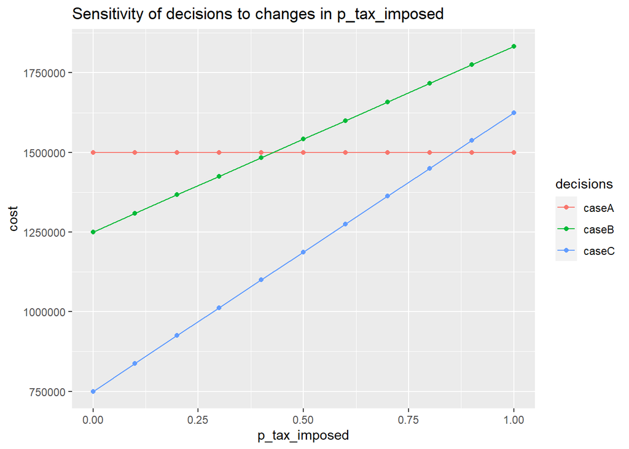

## Utility Function and Certainty Equivalent

Assume that all the information in that exercise still holds, and that DM has an exponential utility function with a risk tolerance of $750,000.

We reuse the code provided in the exercise session with some changes. An helper function CalcUtilityFunction, created specifically for the case study of the DM Systems, is provided below. We can easily see that it is made up of three parts and each one of them calculates the expected value for a branch of the tree apllying on the costs the exponential utility function. In situations involving costs, where less of an evaluation measure is preferred to more, the exponential utility function has the form $u(x) = 1-e^{x/R}$, the certainty equivalent is equal to $CE = R*ln(1-EU)$.

```r
utilityFunctionExp <- function(X, R) {
res <- 1- exp(X/R)
return(res)
}

CertEquivalent = function(EU, R){
CE = R*ln(1-EU)
return(CE)
}

CalcExpectedUtilityFunction <- function(resultTreeDM, R){

UFA = utilityFunctionExp(resultTreeDM$payoff[2], R)
names(UFA)<-"caseA"

UFB = utilityFunctionExp(resultTreeDM$payoff[5:8], R)
UFB_tax_imposed = 1/3*UFB[1]+1/3*UFB[2]+ 1/3*UFB[3]
UFB_tax_not_imposed = UFB[4]
UFB_tot = resultTreeDM$vars[23]*UFB_tax_imposed+resultTreeDM$vars[24]*UFB_tax_not_imposed
names(UFB_tot)<-"caseB"

UFC = utilityFunctionExp(resultTreeDM$payoff[11:14], R)
UFC_tax_imposed = 1/3*UFC[1]+1/3*UFC[2]+ 1/3*UFC[3]
UFC_tax_not_imposed = UFC[4]
UFC_tot = resultTreeDM$vars[23]*UFC_tax_imposed+resultTreeDM$vars[24]*UFC_tax_not_imposed
UFC_tot
names(UFC_tot)<-"caseC"

return (c(UFA, UFB_tot, UFC_tot))
}

CalcBranchCE <- function(resultTreeDM, R){
CE_vett = CertEquivalent(CalcExpectedUtilityFunction(resultTreeDM, R), R)
return(CE_vett)
}

R=750000
vRes = CalcBranchCE(resultTreeDM, R)
vRes
```

```
##   caseA   caseB   caseC
## 1500000 1702172 1509031
```

Using this utility function as the decision criterion, the DM’s preferred ordering alternative for the PAL chips is to buy all of the PAL chips from the IM Chips.  
As expected the certainty equivalent cost is more than the expected value, so the decision maker is risk averse, that is he leans toward less risky resolutions.

## KR revises the offer

```r
treeDMrevises = yaml.load_file(input = "C:\\Users\\Laura\\Google Drive\\MAGISTRALE\\1 anno\\2 SEMESTRE\\decision model\\Assignment\\Assignment 4\\tree-DM - KR revises the offer.yaml")
resultTreeDMrevises =dtree(yl = treeDMrevises, opt="min")
#summary(resultTreeDMrevises, input = FALSE, output = TRUE)

plot(resultTreeDMrevises, final = TRUE)
```

[interactive chart not shown]

c = cancel the order  
nc = not cancel the order  
Assuming that all other information is still valid, the DM’s preferred alternative for the initial order of PAL chips is to buy all of the PAL chips from the KR Electronics. If the antidumping tax is imposed, in the case of 200% tax is imposed, then DM will cancel its entire order, otherwise he will not cancel the order.

## Value of Information

Now we determine the maximum amount that DM should pay for information about whether the antidumping tax will be imposed.  
Note that we determine the amount for information about whether the antidumping tax will be imposed, not for information about whether the tax will be 50%, 100%, or 200% of the sale price. (In this case the maximum amount would be greater).

```r
treeDM_PI = yaml.load_file(input = "C:\\Users\\Laura\\Google Drive\\MAGISTRALE\\1 anno\\2 SEMESTRE\\decision model\\Assignment\\Assignment 4\\tree-DM - PI.yaml")
resultTreeDM_PI =dtree(yl = treeDM_PI, opt = "min")

plot(resultTreeDM_PI, final = TRUE)
```

[interactive chart not shown]

From the analysis of the expected value for this branch of the decision tree, it is possible to deduce that the expected cost in the case of perfect information would be $1200000. We have seen that the expected value of the cost in the uncertain case is $1275000, so we can say that the perfect information in this scenario can not be worth more than 75000 (=1275000-1200000) dollars and, therefore, it would make no sense to buy such information for a higher price.